# ESL_Project

```python
import numpy as np
import pandas as pd
import seaborn as sns
import matplotlib.pyplot as plt
```

Part 1.1 a - Read ‘Car name.csv’ as a DataFrame and assign it to a variable.

```python
carname_df = pd.read_csv('Car name.csv')
carname_df.head()
```

|  | car_name |
| --- | --- |
| 0 | chevrolet chevelle malibu |
| 1 | buick skylark 320 |
| 2 | plymouth satellite |
| 3 | amc rebel sst |
| 4 | ford torino |

Part 1.1 b - Read ‘Car-Attributes.json as a DataFrame and assign it to a variable.

```python
carattributes_df = pd.read_json('Car-Attributes.json')
carattributes_df.head()
```

|  | mpg | cyl | disp | hp | wt | acc | yr | origin |
| --- | --- | --- | --- | --- | --- | --- | --- | --- |
| 0 | 18.0 | 8 | 307.0 | 130 | 3504 | 12.0 | 70 | 1 |
| 1 | 15.0 | 8 | 350.0 | 165 | 3693 | 11.5 | 70 | 1 |
| 2 | 18.0 | 8 | 318.0 | 150 | 3436 | 11.0 | 70 | 1 |
| 3 | 16.0 | 8 | 304.0 | 150 | 3433 | 12.0 | 70 | 1 |
| 4 | 17.0 | 8 | 302.0 | 140 | 3449 | 10.5 | 70 | 1 |

Part 1.1 c - Merge both the DataFrames together to form a single DataFrame

```python
concatenated_df = pd.concat([carname_df, carattributes_df], axis=1)
concatenated_df.head()
```

|  | car_name | mpg | cyl | disp | hp | wt | acc | yr | origin |
| --- | --- | --- | --- | --- | --- | --- | --- | --- | --- |
| 0 | chevrolet chevelle malibu | 18.0 | 8 | 307.0 | 130 | 3504 | 12.0 | 70 | 1 |
| 1 | buick skylark 320 | 15.0 | 8 | 350.0 | 165 | 3693 | 11.5 | 70 | 1 |
| 2 | plymouth satellite | 18.0 | 8 | 318.0 | 150 | 3436 | 11.0 | 70 | 1 |
| 3 | amc rebel sst | 16.0 | 8 | 304.0 | 150 | 3433 | 12.0 | 70 | 1 |
| 4 | ford torino | 17.0 | 8 | 302.0 | 140 | 3449 | 10.5 | 70 | 1 |

Part 1.1 d - Print 5 point summary of the numerical features and share insights.

```python
concatenated_df.info()
```

```
<class 'pandas.core.frame.DataFrame'>
RangeIndex: 398 entries, 0 to 397
Data columns (total 9 columns):
 #   Column    Non-Null Count  Dtype
---  ------    --------------  -----
 0   car_name  398 non-null    object
 1   mpg       398 non-null    float64
 2   cyl       398 non-null    int64
 3   disp      398 non-null    float64
 4   hp        398 non-null    object
 5   wt        398 non-null    int64
 6   acc       398 non-null    float64
 7   yr        398 non-null    int64
 8   origin    398 non-null    int64
dtypes: float64(3), int64(4), object(2)
memory usage: 28.1+ KB
```

Part 1.2 a - Check and print feature-wise percentage of missing values present in the data and impute with the best suitable approach.

```python
missing_percentage = concatenated_df.isnull().mean() * 100
missing_percentage
```

```
car_name    0.0
mpg         0.0
cyl         0.0
disp        0.0
hp          0.0
wt          0.0
acc         0.0
yr          0.0
origin      0.0
dtype: float64
```

Part 1.2 b - Check for duplicate values in the data and impute with the best suitable approach.

```python
duplicate_rows = concatenated_df.duplicated()

print("Duplicate rows:")
print(concatenated_df[duplicate_rows])

num_duplicate_rows = sum(duplicate_rows)
print(f"Number of duplicate rows: {num_duplicate_rows}")
```

```
Duplicate rows:
Empty DataFrame
Columns: [car_name, mpg, cyl, disp, hp, wt, acc, yr, origin]
Index: []
Number of duplicate rows: 0
```

No duplicates found

Part 1.2 c - Plot a pairplot for all features.

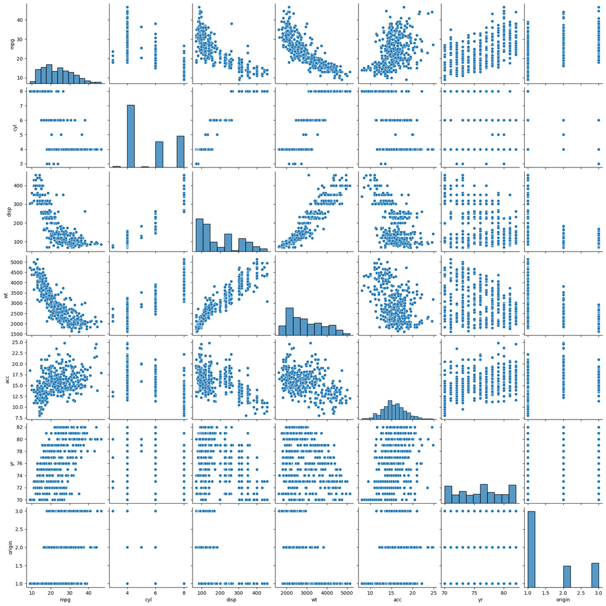

```python
sns.pairplot(concatenated_df)
plt.show()
```

Part 1.2 d - Visualize a scatterplot for ‘wt’ and ‘disp’. Datapoints should be distinguishable by ‘cyl’.

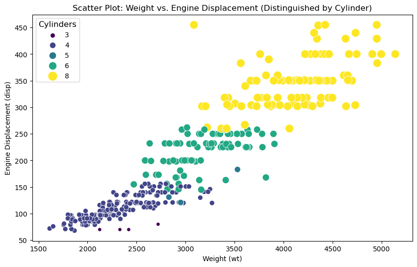

```python
import matplotlib.pyplot as plt

plt.figure(figsize=(10, 6))
sns.scatterplot(x='wt', y='disp', hue='cyl', data=concatenated_df, palette='viridis', size='cyl', sizes=(30, 150))

plt.xlabel('Weight (wt)')
plt.ylabel('Engine Displacement (disp)')
plt.title('Scatter Plot: Weight vs. Engine Displacement (Distinguished by Cylinder)')

plt.legend(title='Cylinders', title_fontsize='12', fontsize='10')
plt.show()
```

Part 1.2 e - Share insights for Q2.d.

From the plot it is evident that there is a positive correlation between weight and engine displacement.

Part 1.2 f - Visualize a scatterplot for ‘wt’ and ’mpg’. Datapoints should be distinguishable by ‘cyl’.

[figure not shown]

```python
plt.figure(figsize=(10, 6))
sns.scatterplot(x='wt', y='mpg', hue='cyl', data=concatenated_df, palette='viridis', size='cyl', sizes=(30, 150))

plt.xlabel('Weight (wt)')
plt.ylabel('Engine Displacement (disp)')
plt.title('Scatter Plot: Weight vs. Mpg (Distinguished by Cylinder)')

plt.legend(title='Cylinders', title_fontsize='12', fontsize='10')
plt.show()
```

Part 1.2 g- Share insights for Q2.f.

From the plot it is evident that there is a negative correlation between weight and Mpg displacement

Part 1.2 h - Check for unexpected values in all the features and datapoints with such values.

```python
concatenated_df['mpg'].unique()
```

```
array([18. , 15. , 16. , 17. , 14. , 24. , 22. , 21. , 27. , 26. , 25. ,
       10. , 11. ,  9. , 28. , 19. , 12. , 13. , 23. , 30. , 31. , 35. ,
       20. , 29. , 32. , 33. , 17.5, 15.5, 14.5, 22.5, 24.5, 18.5, 29.5,
       26.5, 16.5, 31.5, 36. , 25.5, 33.5, 20.5, 30.5, 21.5, 43.1, 36.1,
       32.8, 39.4, 19.9, 19.4, 20.2, 19.2, 25.1, 20.6, 20.8, 18.6, 18.1,
       17.7, 27.5, 27.2, 30.9, 21.1, 23.2, 23.8, 23.9, 20.3, 21.6, 16.2,
       19.8, 22.3, 17.6, 18.2, 16.9, 31.9, 34.1, 35.7, 27.4, 25.4, 34.2,
       34.5, 31.8, 37.3, 28.4, 28.8, 26.8, 41.5, 38.1, 32.1, 37.2, 26.4,
       24.3, 19.1, 34.3, 29.8, 31.3, 37. , 32.2, 46.6, 27.9, 40.8, 44.3,
       43.4, 36.4, 44.6, 40.9, 33.8, 32.7, 23.7, 23.6, 32.4, 26.6, 25.8,
       23.5, 39.1, 39. , 35.1, 32.3, 37.7, 34.7, 34.4, 29.9, 33.7, 32.9,
       31.6, 28.1, 30.7, 24.2, 22.4, 34. , 38. , 44. ])
```

```python
concatenated_df['hp'].unique()
```

```
array([130, 165, 150, 140, 198, 220, 215, 225, 190, 170, 160, 95, 97, 85,
       88, 46, 87, 90, 113, 200, 210, 193, '?', 100, 105, 175, 153, 180,
       110, 72, 86, 70, 76, 65, 69, 60, 80, 54, 208, 155, 112, 92, 145,
       137, 158, 167, 94, 107, 230, 49, 75, 91, 122, 67, 83, 78, 52, 61,
       93, 148, 129, 96, 71, 98, 115, 53, 81, 79, 120, 152, 102, 108, 68,
       58, 149, 89, 63, 48, 66, 139, 103, 125, 133, 138, 135, 142, 77, 62,
       132, 84, 64, 74, 116, 82], dtype=object)
```

```python
concatenated_df.drop('car_name', axis=1, inplace=True)
hpIsDigit = pd.DataFrame(concatenated_df.hp.str.isdigit())
concatenated_df = concatenated_df.replace('?', np.nan)
concatenated_df[hpIsDigit['hp'] == False]
medianFiller = lambda x: x.fillna(x.median())
concatenated_df = concatenated_df.apply(medianFiller,axis=0)

concatenated_df['hp'] = concatenated_df['hp'].astype('float64')
```

```python
concatenated_df['hp'].unique()
```

```
array([130. , 165. , 150. , 140. , 198. , 220. , 215. , 225. , 190. ,
       170. , 160. ,  95. ,  97. ,  85. ,  88. ,  46. ,  87. ,  90. ,
       113. , 200. , 210. , 193. ,  93.5, 100. , 105. , 175. , 153. ,
       180. , 110. ,  72. ,  86. ,  70. ,  76. ,  65. ,  69. ,  60. ,
        80. ,  54. , 208. , 155. , 112. ,  92. , 145. , 137. , 158. ,
       167. ,  94. , 107. , 230. ,  49. ,  75. ,  91. , 122. ,  67. ,
        83. ,  78. ,  52. ,  61. ,  93. , 148. , 129. ,  96. ,  71. ,
        98. , 115. ,  53. ,  81. ,  79. , 120. , 152. , 102. , 108. ,
        68. ,  58. , 149. ,  89. ,  63. ,  48. ,  66. , 139. , 103. ,
       125. , 133. , 138. , 135. , 142. ,  77. ,  62. , 132. ,  84. ,
        64. ,  74. , 116. ,  82. ])
```

```python
concatenated_df['wt'].unique()
```

```
array([3504, 3693, 3436, 3433, 3449, 4341, 4354, 4312, 4425, 3850, 3563,
       3609, 3761, 3086, 2372, 2833, 2774, 2587, 2130, 1835, 2672, 2430,
       2375, 2234, 2648, 4615, 4376, 4382, 4732, 2264, 2228, 2046, 2634,
       3439, 3329, 3302, 3288, 4209, 4464, 4154, 4096, 4955, 4746, 5140,
       2962, 2408, 3282, 3139, 2220, 2123, 2074, 2065, 1773, 1613, 1834,
       1955, 2278, 2126, 2254, 2226, 4274, 4385, 4135, 4129, 3672, 4633,
       4502, 4456, 4422, 2330, 3892, 4098, 4294, 4077, 2933, 2511, 2979,
       2189, 2395, 2288, 2506, 2164, 2100, 4100, 3988, 4042, 3777, 4952,
       4363, 4237, 4735, 4951, 3821, 3121, 3278, 2945, 3021, 2904, 1950,
       4997, 4906, 4654, 4499, 2789, 2279, 2401, 2379, 2124, 2310, 2472,
       2265, 4082, 4278, 1867, 2158, 2582, 2868, 3399, 2660, 2807, 3664,
       3102, 2875, 2901, 3336, 2451, 1836, 2542, 3781, 3632, 3613, 4141,
       4699, 4457, 4638, 4257, 2219, 1963, 2300, 1649, 2003, 2125, 2108,
       2246, 2489, 2391, 2000, 3264, 3459, 3432, 3158, 4668, 4440, 4498,
       4657, 3907, 3897, 3730, 3785, 3039, 3221, 3169, 2171, 2639, 2914,
```

[output cut: 18 more lines]

```python
concatenated_df['acc'].unique()
```

```
array([12. , 11.5, 11. , 10.5, 10. ,  9. ,  8.5,  8. ,  9.5, 15. , 15.5,
       16. , 14.5, 20.5, 17.5, 12.5, 14. , 13.5, 18.5, 19. , 13. , 19.5,
       18. , 17. , 23.5, 16.5, 21. , 16.9, 14.9, 17.7, 15.3, 13.9, 12.8,
       15.4, 17.6, 22.2, 22.1, 14.2, 17.4, 16.2, 17.8, 12.2, 16.4, 13.6,
       15.7, 13.2, 21.9, 16.7, 12.1, 14.8, 18.6, 16.8, 13.7, 11.1, 11.4,
       18.2, 15.8, 15.9, 14.1, 21.5, 14.4, 19.4, 19.2, 17.2, 18.7, 15.1,
       13.4, 11.2, 14.7, 16.6, 17.3, 15.2, 14.3, 20.1, 24.8, 11.3, 12.9,
       18.8, 18.1, 17.9, 21.7, 23.7, 19.9, 21.8, 13.8, 12.6, 16.1, 20.7,
       18.3, 20.4, 19.6, 17.1, 15.6, 24.6, 11.6])
```

```python
concatenated_df['yr'].unique()
```

```
array([70, 71, 72, 73, 74, 75, 76, 77, 78, 79, 80, 81, 82], dtype=int64)
```

```python
concatenated_df['origin'].unique()
```

```
array([1, 3, 2], dtype=int64)
```

Part 1.3 a - Apply K-Means clustering for 2 to 10 clusters.

Part 1.3 b - Plot a visual and find elbow point.

Part 1.3 c - On the above visual, highlight which are the possible Elbow points.

```python
from scipy.stats import zscore

df_standardized = concatenated_df.apply(zscore)


print(df_standardized)
```

```
          mpg       cyl      disp        hp        wt       acc        yr  \
0   -0.706439  1.498191  1.090604  0.673118  0.630870 -1.295498 -1.627426
1   -1.090751  1.498191  1.503514  1.589958  0.854333 -1.477038 -1.627426
2   -0.706439  1.498191  1.196232  1.197027  0.550470 -1.658577 -1.627426
3   -0.962647  1.498191  1.061796  1.197027  0.546923 -1.295498 -1.627426
4   -0.834543  1.498191  1.042591  0.935072  0.565841 -1.840117 -1.627426
..        ...       ...       ...       ...       ...       ...       ...
393  0.446497 -0.856321 -0.513026 -0.479482 -0.213324  0.011586  1.621983
394  2.624265 -0.856321 -0.925936 -1.370127 -0.993671  3.279296  1.621983
395  1.087017 -0.856321 -0.561039 -0.531873 -0.798585 -1.440730  1.621983
396  0.574601 -0.856321 -0.705077 -0.662850 -0.408411  1.100822  1.621983
397  0.958913 -0.856321 -0.714680 -0.584264 -0.296088  1.391285  1.621983

       origin
0   -0.715145
1   -0.715145
2   -0.715145
3   -0.715145
4   -0.715145
..        ...
393 -0.715145
394  0.533222
395 -0.715145
396 -0.715145
397 -0.715145

[398 rows x 8 columns]
```

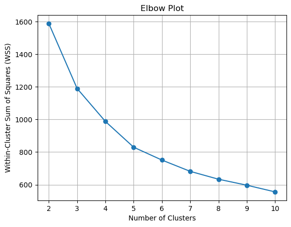

```
Elbow Point (Optimal Number of Clusters): 5
```

```python
from kneed import KneeLocator
from sklearn.cluster import KMeans
from sklearn.preprocessing import StandardScaler

min_clusters = 2
max_clusters = 10

wss = []  # Within-Cluster Sum of Squares (WSS) values

for n_clusters in range(min_clusters, max_clusters + 1):
    kmeans = KMeans(n_clusters=n_clusters, random_state=42)
    kmeans.fit(df_standardized)
    wss.append(kmeans.inertia_)

# Step 2: Plot the Elbow plot
plt.plot(range(min_clusters, max_clusters + 1), wss, marker='o')
plt.xlabel('Number of Clusters')
plt.ylabel('Within-Cluster Sum of Squares (WSS)')
plt.title('Elbow Plot')
plt.xticks(range(min_clusters, max_clusters + 1))
plt.grid(True)
plt.show()

# Step 3: Use "kneed" library to find the elbow point
elbow_point = KneeLocator(range(min_clusters, max_clusters + 1), wss, curve='convex', direction='decreasing').elbow

# Step 4: Print the elbow point (optimal number of clusters)
print("Elbow Point (Optimal Number of Clusters):", elbow_point)
```

Part 1.3 d - Train a K-means clustering model once again on the optimal number of clusters.

Part 1.3 e - Add a new feature in the DataFrame which will have labels based upon cluster value

```python
from sklearn.cluster import KMeans
from sklearn.preprocessing import StandardScaler

elbow_point = 5

kmeans = KMeans(n_clusters=elbow_point, random_state=42)
cluster_labels = kmeans.fit_predict(df_standardized)

df_standardized['Cluster'] = cluster_labels

cluster_stats = df_standardized.groupby('Cluster').mean()
print(cluster_stats)
```

```
              mpg       cyl      disp        hp        wt       acc        yr  \
Cluster
0       -0.564892  0.451742  0.384281 -0.063427  0.387993  0.386319 -0.082954
1        1.360839 -0.807268 -0.901663 -0.823297 -0.963144  0.423579  0.922458
2        0.675937 -0.742109 -0.584400 -0.561587 -0.480763  0.356240  0.991501
3        0.141488 -0.828291 -0.814535 -0.488058 -0.736371  0.195719 -0.731260
4       -1.163797  1.498191  1.503923  1.521683  1.404098 -1.086149 -0.688324

           origin
Cluster
0       -0.668909
1        1.486835
2       -0.621983
3        0.666976
4       -0.715145
```

Part 1.3 f -Plot a visual and color the datapoints based upon clusters.

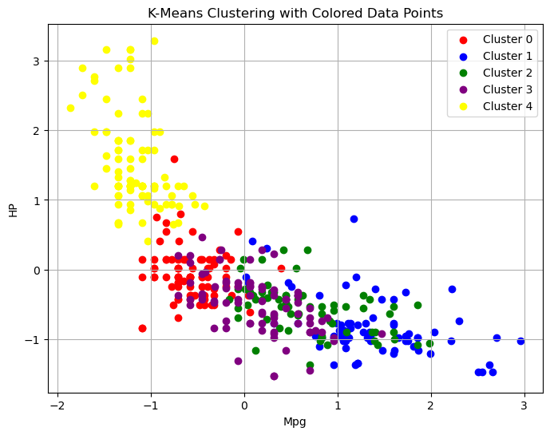

```python
plt.figure(figsize=(8, 6))

colors = ['red', 'blue', 'green', 'purple', 'yellow']

for cluster_num in range(elbow_point):
    cluster_data = df_standardized[df_standardized['Cluster'] == cluster_num]

    plt.scatter(cluster_data['mpg'], cluster_data['hp'], color=colors[cluster_num], label=f'Cluster {cluster_num}')

plt.legend()
plt.xlabel('Mpg')
plt.ylabel('HP')
plt.title('K-Means Clustering with Colored Data Points')
plt.grid(True)
plt.show()
```

Part 1.3 g - Pass a new DataPoint and predict which cluster it belongs to.

```python
new_data_point = [25,4, 150, 95, 3000, 15, 80, 1]

new_data_point_reshaped = np.reshape(new_data_point, (1, -1))
new_data_point_reshaped

# Predict the cluster for the new data point using the trained K-Means model
predicted_cluster = kmeans.predict(new_data_point_reshaped)

print("Predicted Cluster:", predicted_cluster[0])
```

```
Predicted Cluster: 4
```

Part 2. 1 a - Read ‘vehicle.csv’ and save as DataFrame.

```python
vehicle_df = pd.read_csv('vehicle.csv')
vehicle_df.head()
```

|  | compactness | circularity | distance_circularity | radius_ratio | pr.axis_aspect_ratio | max.length_aspect_ratio | scatter_ratio | elongatedness | pr.axis_rectangularity | max.length_rectangularity | scaled_variance | scaled_variance.1 | scaled_radius_of_gyration | scaled_radius_of_gyration.1 | skewness_about | skewness_about.1 | skewness_about.2 | hollows_ratio | class |
| --- | --- | --- | --- | --- | --- | --- | --- | --- | --- | --- | --- | --- | --- | --- | --- | --- | --- | --- | --- |
| 0 | 95 | 48.0 | 83.0 | 178.0 | 72.0 | 10 | 162.0 | 42.0 | 20.0 | 159 | 176.0 | 379.0 | 184.0 | 70.0 | 6.0 | 16.0 | 187.0 | 197 | van |
| 1 | 91 | 41.0 | 84.0 | 141.0 | 57.0 | 9 | 149.0 | 45.0 | 19.0 | 143 | 170.0 | 330.0 | 158.0 | 72.0 | 9.0 | 14.0 | 189.0 | 199 | van |
| 2 | 104 | 50.0 | 106.0 | 209.0 | 66.0 | 10 | 207.0 | 32.0 | 23.0 | 158 | 223.0 | 635.0 | 220.0 | 73.0 | 14.0 | 9.0 | 188.0 | 196 | car |
| 3 | 93 | 41.0 | 82.0 | 159.0 | 63.0 | 9 | 144.0 | 46.0 | 19.0 | 143 | 160.0 | 309.0 | 127.0 | 63.0 | 6.0 | 10.0 | 199.0 | 207 | van |
| 4 | 85 | 44.0 | 70.0 | 205.0 | 103.0 | 52 | 149.0 | 45.0 | 19.0 | 144 | 241.0 | 325.0 | 188.0 | 127.0 | 9.0 | 11.0 | 180.0 | 183 | bus |

Part 2.1 b- Check percentage of missing values and impute with correct approach.

```python
missing_values = vehicle_df.isnull()

missing_values_count = vehicle_df.isnull().sum()

print("Missing Values:\n", missing_values)
print("\nMissing Values Count:\n", missing_values_count)
```

[output not shown]

[output cut: 47 more lines]

```
max.length_aspect_ratio        0
scatter_ratio                  1
elongatedness                  1
pr.axis_rectangularity         3
max.length_rectangularity      0
scaled_variance                3
scaled_variance.1              2
scaled_radius_of_gyration      2
scaled_radius_of_gyration.1    4
skewness_about                 6
skewness_about.1               1
skewness_about.2               1
hollows_ratio                  0
class                          0
dtype: int64
```

```python
percent_missing = (vehicle_df.isnull().sum() / len(vehicle_df)) * 100
print("Percentage of Missing Values:\n", percent_missing)
```

```
Percentage of Missing Values:
 compactness                    0.000000
circularity                    0.591017
distance_circularity           0.472813
radius_ratio                   0.709220
pr.axis_aspect_ratio           0.236407
max.length_aspect_ratio        0.000000
scatter_ratio                  0.118203
elongatedness                  0.118203
pr.axis_rectangularity         0.354610
max.length_rectangularity      0.000000
scaled_variance                0.354610
scaled_variance.1              0.236407
scaled_radius_of_gyration      0.236407
scaled_radius_of_gyration.1    0.472813
skewness_about                 0.709220
skewness_about.1               0.118203
skewness_about.2               0.118203
hollows_ratio                  0.000000
class                          0.000000
dtype: float64
```

```python
vehicle_df.dropna(inplace=True)
```

```python
percent_missing = (vehicle_df.isnull().sum() / len(vehicle_df)) * 100
print("Percentage of Missing Values:\n", percent_missing)
```

```
Percentage of Missing Values:
 compactness                    0.0
circularity                    0.0
distance_circularity           0.0
radius_ratio                   0.0
pr.axis_aspect_ratio           0.0
max.length_aspect_ratio        0.0
scatter_ratio                  0.0
elongatedness                  0.0
pr.axis_rectangularity         0.0
max.length_rectangularity      0.0
scaled_variance                0.0
scaled_variance.1              0.0
scaled_radius_of_gyration      0.0
scaled_radius_of_gyration.1    0.0
skewness_about                 0.0
skewness_about.1               0.0
skewness_about.2               0.0
hollows_ratio                  0.0
class                          0.0
dtype: float64
```

Part 2.1 c- Visualize a Pie-chart and print percentage of values for variable ‘class’.

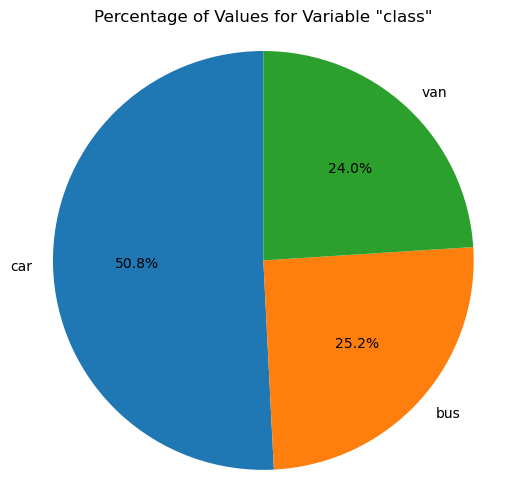

```
Percentage of Values for Variable 'class':
car    50.799508
bus    25.215252
van    23.985240
Name: class, dtype: float64
```

```python
class_counts = vehicle_df['class'].value_counts()

plt.figure(figsize=(6, 6))
plt.pie(class_counts, labels=class_counts.index, autopct='%1.1f%%', startangle=90)
plt.title('Percentage of Values for Variable "class"')
plt.axis('equal')
plt.show()

print("Percentage of Values for Variable 'class':")
print(class_counts / len(vehicle_df) * 100)
```

Part 2.1 d - Check for duplicate rows in the data and impute with correct approach.

```python
duplicate_rows = vehicle_df.duplicated()
print("Duplicate Rows:")
print(vehicle_df[duplicate_rows])
```

```
Duplicate Rows:
Empty DataFrame
Columns: [compactness, circularity, distance_circularity, radius_ratio, pr.axis_aspect_ratio, max.length_aspect_ratio, scatter_ratio, elongatedness, pr.axis_rectangularity, max.length_rectangularity, scaled_variance, scaled_variance.1, scaled_radius_of_gyration, scaled_radius_of_gyration.1, skewness…
Index: []
```

```python
duplicate_rows = vehicle_df.duplicated()

duplicate_rows_count = duplicate_rows.sum()

print("Count of Duplicate Rows:", duplicate_rows_count)
```

```
Count of Duplicate Rows: 0
```

No duplicate rows

Part 2.2 a - Split data into X and Y.

```python
X = vehicle_df.drop('class', axis=1)
Y = vehicle_df['class']
```

Part 2.2 b - Standardize the Data.

```python
from scipy.stats import zscore
XScaled=X.apply(zscore)
XScaled.head()
```

|  | compactness | circularity | distance_circularity | radius_ratio | pr.axis_aspect_ratio | max.length_aspect_ratio | scatter_ratio | elongatedness | pr.axis_rectangularity | max.length_rectangularity | scaled_variance | scaled_variance.1 | scaled_radius_of_gyration | scaled_radius_of_gyration.1 | skewness_about | skewness_about.1 | skewness_about.2 | hollows_ratio |
| --- | --- | --- | --- | --- | --- | --- | --- | --- | --- | --- | --- | --- | --- | --- | --- | --- | --- | --- |
| 0 | 0.163231 | 0.520408 | 0.060669 | 0.264970 | 1.283254 | 0.299721 | -0.198517 | 0.129648 | -0.217151 | 0.766312 | -0.397397 | -0.339014 | 0.301676 | -0.321192 | -0.071523 | 0.371287 | -0.321809 | 0.171837 |
| 1 | -0.322874 | -0.619123 | 0.124067 | -0.836393 | -0.599253 | 0.085785 | -0.591720 | 0.514333 | -0.606014 | -0.337462 | -0.590034 | -0.618754 | -0.502972 | -0.053505 | 0.538425 | 0.147109 | 0.003400 | 0.442318 |
| 2 | 1.256966 | 0.845988 | 1.518823 | 1.187734 | 0.530251 | 0.299721 | 1.162569 | -1.152637 | 0.949438 | 0.697326 | 1.111591 | 1.122486 | 1.415804 | 0.080339 | 1.555006 | -0.413338 | -0.159204 | 0.036596 |
| 3 | -0.079822 | -0.619123 | -0.002729 | -0.300595 | 0.153750 | 0.085785 | -0.742952 | 0.642562 | -0.606014 | -0.337462 | -0.911095 | -0.738643 | -1.462359 | -1.258099 | -0.071523 | -0.301249 | 1.629444 | 1.524243 |
| 4 | -1.052030 | -0.130753 | -0.763506 | 1.068668 | 5.173770 | 9.285029 | -0.591720 | 0.514333 | -0.606014 | -0.268476 | 1.689501 | -0.647299 | 0.425468 | 7.307905 | 0.538425 | -0.189159 | -1.460039 | -1.721531 |

Part 2.3 a - Train a base Classification model using SVM.

Part 2.3 b - Print Classification metrics for train data.

```python
from sklearn.model_selection import train_test_split
from sklearn.svm import SVC
from sklearn.metrics import accuracy_score, classification_report, confusion_matrix


# Split the data into 80% training and 20% test sets
X_train, X_test, y_train, y_test = train_test_split(X, Y, test_size=0.2, random_state=42)

# Create and train the SVM model with RBF kernel
svm_model = SVC(kernel='rbf', C=1.0, random_state=42)
svm_model.fit(X_train, y_train)

y_train_pred = svm_model.predict(X_train)
y_test_pred = svm_model.predict(X_test)

train_accuracy = accuracy_score(y_train, y_train_pred)
test_accuracy = accuracy_score(y_test, y_test_pred)

print("Train Accuracy:", train_accuracy)
print("Test Accuracy:", test_accuracy)

classification_rep = classification_report(y_test, y_test_pred)
conf_matrix = confusion_matrix(y_test, y_test_pred)

print("Classification Report:\n", classification_rep)
print("Confusion Matrix:\n", conf_matrix)
```

```
Train Accuracy: 0.6876923076923077
Test Accuracy: 0.6625766871165644
Classification Report:
               precision    recall  f1-score   support

         bus       0.50      0.47      0.49        36
         car       0.84      0.75      0.79        97
         van       0.43      0.60      0.50        30

    accuracy                           0.66       163
   macro avg       0.59      0.61      0.59       163
weighted avg       0.69      0.66      0.67       163

Confusion Matrix:
 [[17 14  5]
 [ 5 73 19]
 [12  0 18]]
```

Part 2.3 c - Apply PCA on the data with 10 components.

```python
from sklearn.decomposition import PCA
pca = PCA(n_components=10)
X_pca = pca.fit_transform(XScaled)
```

Part 2.3 d - Visualize Cumulative Variance Explained with Number of Components.

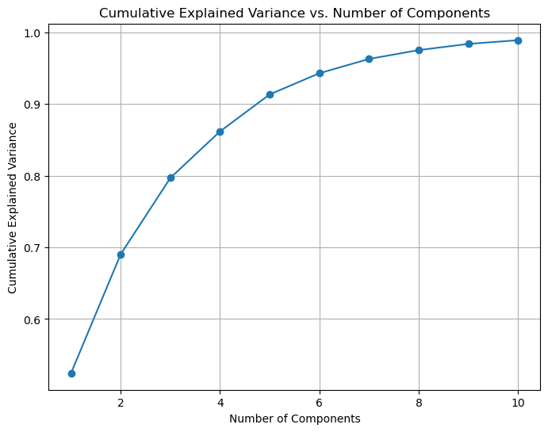

```python
n_components=10
cumulative_variance = np.cumsum(pca.explained_variance_ratio_)

plt.figure(figsize=(8, 6))
plt.plot(range(1, n_components + 1), cumulative_variance, marker='o')
plt.xlabel('Number of Components')
plt.ylabel('Cumulative Explained Variance')
plt.title('Cumulative Explained Variance vs. Number of Components')
plt.grid(True)
plt.show()
```

Part 2.3 e - Draw a horizontal line on the above plot to highlight the threshold of 90%.

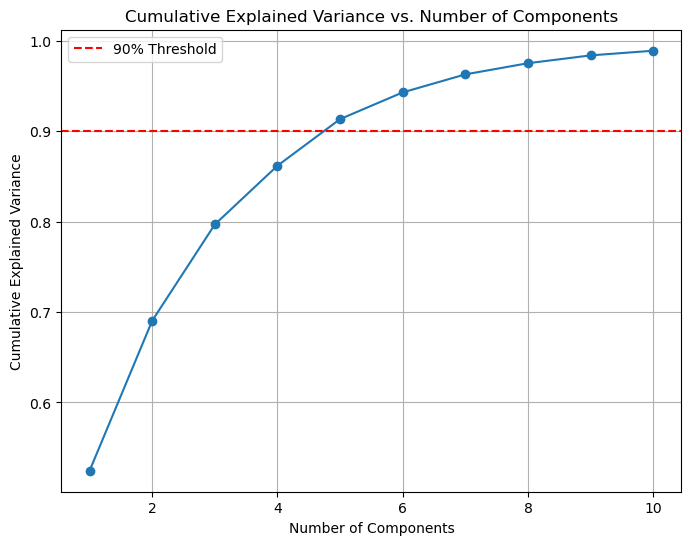

```python
plt.figure(figsize=(8, 6))
plt.plot(range(1, n_components + 1), cumulative_variance, marker='o')
plt.xlabel('Number of Components')
plt.ylabel('Cumulative Explained Variance')
plt.title('Cumulative Explained Variance vs. Number of Components')
plt.grid(True)
plt.axhline(y=0.9, color='red', linestyle='--', label='90% Threshold')
plt.legend()

plt.show()
```

Part 2.3 f - Apply PCA on the data. This time Select Minimum Components with 90% or above variance explained.

```python
pca = PCA()
X_pca = pca.fit_transform(XScaled)

cumulative_variance = np.cumsum(pca.explained_variance_ratio_)

min_components = np.argmax(cumulative_variance >= 0.9) + 1

pca = PCA(n_components=min_components)
X_pca_min = pca.fit_transform(XScaled)
```

Part 2.3 g - Train SVM model on components selected from above step.

Part 2.3 h - Print Classification metrics for train data of above model and share insights.

```python
X_train, X_test, Y_train, Y_test = train_test_split(X_pca_min, Y, test_size=0.2, random_state=42)

svm_model = SVC(kernel='linear')

svm_model.fit(X_train, Y_train)

Y_pred = svm_model.predict(X_test)

accuracy = accuracy_score(Y_test, Y_pred)
print("Accuracy:", accuracy)

print("Classification Report:")
print(classification_report(Y_test, Y_pred))
# Print confusion matrix
print("Confusion Matrix:")
print(confusion_matrix(Y_test, Y_pred))
```

```
Accuracy: 0.6993865030674846
Classification Report:
              precision    recall  f1-score   support

         bus       0.56      0.53      0.54        36
         car       0.83      0.82      0.83        97
         van       0.45      0.50      0.48        30

    accuracy                           0.70       163
   macro avg       0.62      0.62      0.62       163
weighted avg       0.70      0.70      0.70       163

Confusion Matrix:
[[19 12  5]
 [ 4 80 13]
 [11  4 15]]
```

1.The SVM model performs well for the "car" class but struggles with the "van" class.

2.Need to improve the model's performance for the "bus" and "van" classes, as they seem to be the most challenging to classify accurately.

Part 2.4 a - Train another SVM on the components out of PCA. Tune the parameters to improve performance.

```python
pca = PCA(n_components=0.9)  # Select components with 90% variance explained
X_pca = pca.fit_transform(XScaled)

X_train, X_test, Y_train, Y_test = train_test_split(X_pca, Y, test_size=0.2, random_state=42)
```

Part 2.4 b- Share best Parameters observed from above step.

```python
from sklearn.model_selection import train_test_split, GridSearchCV
param_grid = {
    'C': [0.1, 1, 10],
    'kernel': ['linear', 'rbf', 'poly'],
    'gamma': ['scale', 'auto', 0.1, 0.01]
}

svm_model = SVC()

grid_search = GridSearchCV(svm_model, param_grid, cv=5, n_jobs=-1)
grid_search.fit(X_train, Y_train)

best_params = grid_search.best_params_
print("Best Hyperparameters:", best_params)
```

```
Best Hyperparameters: {'C': 10, 'gamma': 'auto', 'kernel': 'rbf'}
```

Part 2.4 c- Print Classification metrics for train data of above model and share relative improvement in performance in all the models along with insights.

```python
best_svm_model = SVC(**best_params)

best_svm_model.fit(X_train, Y_train)

Y_pred = best_svm_model.predict(X_test)

accuracy = accuracy_score(Y_test, Y_pred)
print("Accuracy:", accuracy)

print("Classification Report:")
print(classification_report(Y_test, Y_pred))

print("Confusion Matrix:")
print(confusion_matrix(Y_test, Y_pred))
```

```
Accuracy: 0.7730061349693251
Classification Report:
              precision    recall  f1-score   support

         bus       0.67      0.81      0.73        36
         car       0.92      0.80      0.86        97
         van       0.54      0.63      0.58        30

    accuracy                           0.77       163
   macro avg       0.71      0.75      0.73       163
weighted avg       0.79      0.77      0.78       163

Confusion Matrix:
[[29  4  3]
 [ 6 78 13]
 [ 8  3 19]]
```

Comparison:

Accuracy: The new model after tuning (77.3%) outperforms previous model (69.9%) in terms of accuracy. It has a higher percentage of correct predictions on the test set.

F1-Score: The new model after tuning (0.78) has a slightly higher F1-score compared to previous (0.70). The F1-score considers both precision and recall, providing a balance between the two metrics.

Precision: The new model after tuning (0.79) has a higher precision than previous model (0.70). It means that new model has a higher proportion of true positive predictions among all positive predictions.

Recall: The new model after tuning (0.77) has a higher recall than previous model (0.70). It indicates that new model can correctly identify a higher proportion of actual positive instances.

Part 2.5 a - Explain pre-requisite/assumptions of PCA.

1.PCA assumes linearity and orthogonality to find uncorrelated principal components.

2.It maximizes variance along components, reducing data dimensions.

3.Data should be mean-centered and scaled for effective PCA results.

4.Interpretability of components may be limited due to their linear combinations of original features.

Part 2.5 b - Explain advantages and limitations of PCA.

Advantages of PCA:

Makes data simpler: PCA helps turn big problems into smaller, easier ones by reducing the number of features.

Uncovers hidden patterns: It helps find secret patterns in the data that make it easier to understand.

Reduces noise: PCA can clean up noisy data and make it clearer and easier to work with.

Faster computations: By using PCA, we can do calculations faster and still get useful results.

Limitations of PCA:

Only works with straight lines: PCA can only handle data that follows straight-line patterns, not curves or bends.

Not easy to explain: The new data created by PCA might be harder to explain in simple terms.

Can lose some details: While PCA simplifies data, it may lose some specific details in the process.

Gets affected by strange values: If there are unusual or weird data points, PCA might give less accurate results.